# Init

```r
suppressPackageStartupMessages({
  library(Seurat)
  library(Signac)
  library(tidyverse)
  library(HGNChelper)
})

mbrain <- readRDS("../data/mbrain_seurat.rds")
```

# Differential Expression (DE) analysis

The cell type classification will be performed on the RNA expression only, since most information is available for marker genes less for motifs. To find genes most useful for assigning clusters a Differential Expression analysis is performed.

Alternatively, ChooseR could be used for a more restrictive set of marker genes for each cluster (10.1186/s12859-021-03957-4), but I decided that the default Seurat method performs good enough for this analysis.

```r
DefaultAssay(mbrain) = "SCT" # run marker finding on normalized RNA data
mbrain.markers <- FindAllMarkers(mbrain, only.pos = T) # DE; relies on presto for fast wilcox test
```

## Plot top 5 DE genes in every cluster

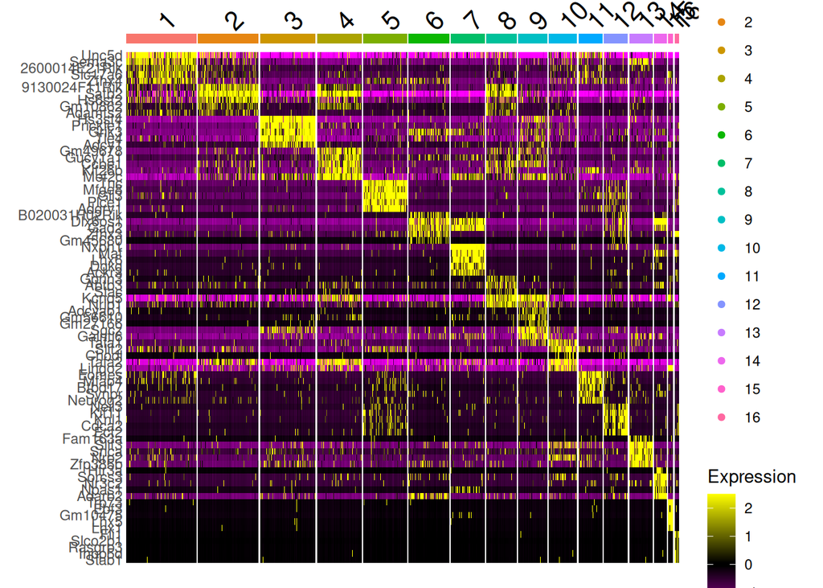

```r
mbrain.markers %>%
  group_by(cluster) %>%
  dplyr::filter(avg_log2FC > 2) %>%
  arrange(cluster, p_val_adj) %>%
  slice_head(n = 5) %>%
  ungroup() -> top

# top %>% count(cluster)

DoHeatmap(mbrain, features = top$gene)
```

```r
ggsave("../figures/cluster_ident/clusters.topgenes.png", dpi=300, width=7, height=7)
```

## cell type annotation using sc-type

I utilize the marker gene collection from sc-type (https://github.com/IanevskiAleksandr/sc-type/). Some caveats: this is a collection of human marker genes, but most gene names are interchangeable between mice and humans when taking into account the writing conventions (capital first letter in mice).

```r
sctype.markers <- read_csv("../data/sc-type_brain.csv") %>%
  mutate(gene = str_split(gene, ";")) %>%
  unnest(gene) %>%
  mutate(gene = str_to_sentence(gene))
```

I join the marker genes with the markers that were discovered in the DE analysis.

```r
# only retain the top 10 that have at least 3 occurences
top.annot <- left_join(mbrain.markers, sctype.markers, by="gene") %>%
  drop_na() %>%
  group_by(cluster) %>%
  dplyr::count(celltype) %>%
  arrange(cluster, desc(n)) %>%
  slice_head(n=10) %>% ungroup() %>%
  dplyr::filter(n>=3)
```

# Cluster per Cluster annotation

This dataset contains brain cells from a late developmental stage of a mouse embryo. Therefore, we expect cells during differentiation and unclear cell identity.

## Neurons

```r
top.annot %>%
  dplyr::filter(str_detect(celltype, "[Nn]euron")) %>%
  group_by(cluster) %>% summarise(sum = sum(n))
```

```
## # A tibble: 12 × 2
##    cluster   sum
##    <fct>   <int>
##  1 1           7
##  2 2           7
##  3 3           9
##  4 4          10
##  5 6           7
##  6 7           7
##  7 8          12
##  8 9          10
##  9 10         11
## 10 13         11
## 11 14          4
## 12 15          4
```

### GABAergic neurons

```r
top.annot %>%
  dplyr::filter(str_detect(celltype, "GABA"))
```

```
## # A tibble: 9 × 3
##   cluster celltype              n
##   <fct>   <chr>             <int>
## 1 4       GABA                  3
## 2 6       GABA                  8
## 3 6       GABAergic neurons     4
## 4 7       GABA                 15
## 5 7       GABAergic neurons     4
## 6 11      GABA                  4
## 7 12      GABA                  8
## 8 14      GABA                  8
## 9 14      GABAergic neurons     4
```

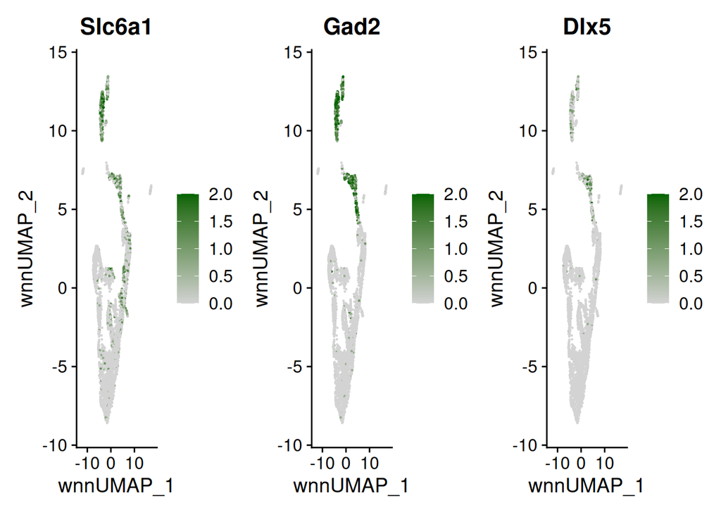

```r
FeaturePlot(mbrain, features = c("Slc6a1", "Gad2", "Dlx5"),
                  reduction = 'wnn.umap', max.cutoff = 2,
                  cols = c("lightgrey","darkgreen"), ncol = 3, pt.size = 1e-2)
```

```r
ggsave("../figures/cluster_ident/Slca1.Gad2.Dlx5.png", dpi=300, width=8, height=3)

top.annot %>%
  dplyr::filter(cluster %in% c(7, 14, 6, 11))
```

```
## # A tibble: 27 × 3
##    cluster celltype                    n
##    <fct>   <chr>                   <int>
##  1 6       GABA                        8
##  2 6       Activated Microglia         4
##  3 6       GABAergic neurons           4
##  4 6       Dentate Hilum (CA4)         3
##  5 6       Immature neurons            3
##  6 6       Neural Progenitor cells     3
##  7 6       Neuroblasts                 3
##  8 6       Polydendrocytes             3
##  9 7       GABA                       15
## 10 7       GABAergic neurons           4
## # ℹ 17 more rows
```

c6 are likely neurons that are on the path to becoming GABAergic. c7 + c14 are more differentiated GABAergic neurons.

c11 are more basal, likely they are simply immature dentate granule cells.

### Glutamatergic neurons

```r
top.annot %>%
  dplyr::filter(str_detect(celltype, "Gluta"))
```

```
## # A tibble: 6 × 3
##   cluster celltype                  n
##   <fct>   <chr>                 <int>
## 1 3       Glutamatergic neurons     4
## 2 4       Glutamatergic neurons     5
## 3 8       Glutamatergic neurons     3
## 4 9       Glutamatergic neurons     4
## 5 10      Glutamatergic neurons     5
## 6 13      Glutamatergic neurons     5
```

```r
mbrain.markers %>%
  dplyr::filter(str_detect(gene, "^Grin1$")) %>%  arrange(p_val_adj)
```

```
##               p_val avg_log2FC pct.1 pct.2    p_val_adj cluster  gene
## Grin11 3.258976e-25  1.0039542 0.549 0.279 6.720987e-21       4 Grin1
## Grin1  5.953366e-21  0.9182845 0.489 0.280 1.227763e-16       3 Grin1
## Grin14 3.929639e-10  0.6955065 0.485 0.291 8.104094e-06       9 Grin1
## Grin15 2.179638e-09  0.7342422 0.484 0.291 4.495068e-05      10 Grin1
## Grin17 1.534374e-07  1.3221399 0.650 0.298 3.164339e-03      15 Grin1
## Grin16 3.040581e-05  0.5199330 0.446 0.295 6.270589e-01      13 Grin1
## Grin12 9.464098e-03  0.4547740 0.368 0.297 1.000000e+00       7 Grin1
## Grin13 1.856338e-03  0.4247375 0.393 0.296 1.000000e+00       8 Grin1
```

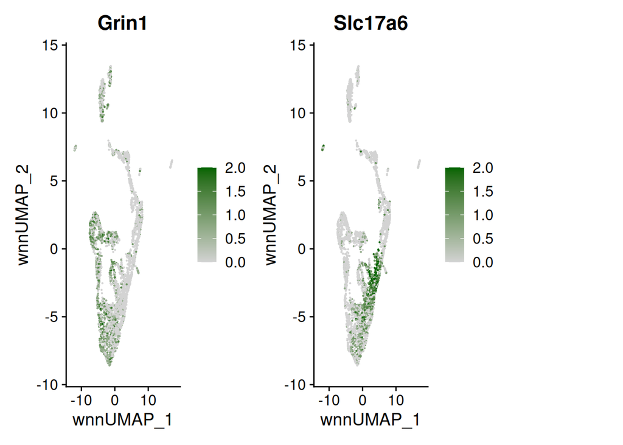

```r
FeaturePlot(mbrain, features = c("Grin1", "Slc17a6"),
                  reduction = 'wnn.umap', max.cutoff = 2,
                  cols = c("lightgrey","darkgreen"), ncol = 3, pt.size = 1e-4)
```

```r
ggsave("../figures/cluster_ident/Grin1.Slc17a6.png", dpi=300, width=8, height=3)

top.annot %>%
  dplyr::filter(cluster %in% c(3, 4, 8, 9, 10, 13))
```

```
## # A tibble: 59 × 3
##    cluster celltype                          n
##    <fct>   <chr>                         <int>
##  1 3       CA1-dorsal Principal              5
##  2 3       Mature neurons                    5
##  3 3       CA3-dorsal Principal              4
##  4 3       Glutamatergic neurons             4
##  5 3       Polydendrocytes                   4
##  6 3       (Pro-) Subiculum                  3
##  7 3       Astrocytes                        3
##  8 3       Endothelial                       3
##  9 3       Microglial cells                  3
## 10 3       Non myelinating Schwann cells     3
## # ℹ 49 more rows
```

The ‘lower left’ portion of the UMAP (clusters 3, 4, 8, 9, 10, and 13) contains cells that are developing into Glutamatergic neurons. They are likely at varying stages of differentiation and slight differences might be explainable by them originating from different regions in the brain.

For simplicity’s sake I will classify clusters c4, c8, c10 as neural progenitor cells; c9 as Glutamatergic progenitors; c3 and c13 as Glutamatergic neurons;

## Glial cells

### astrocytes

```r
top.annot %>%
  dplyr::filter(str_detect(celltype, "Astro"))
```

```
## # A tibble: 13 × 3
##    cluster celltype              n
##    <fct>   <chr>             <int>
##  1 3       Astrocytes            3
##  2 5       Astrocytes           20
##  3 5       Agt Astrocytes       18
##  4 5       Unc13c Astrocytes    16
##  5 5       Gfap++ Astrocytes    12
##  6 8       Agt Astrocytes        5
##  7 8       Astrocytes            4
##  8 8       Gfap++ Astrocytes     4
##  9 11      Astrocytes            7
## 10 11      Agt Astrocytes        4
## 11 12      Agt Astrocytes       10
## 12 12      Astrocytes            9
## 13 12      Unc13c Astrocytes     8
```

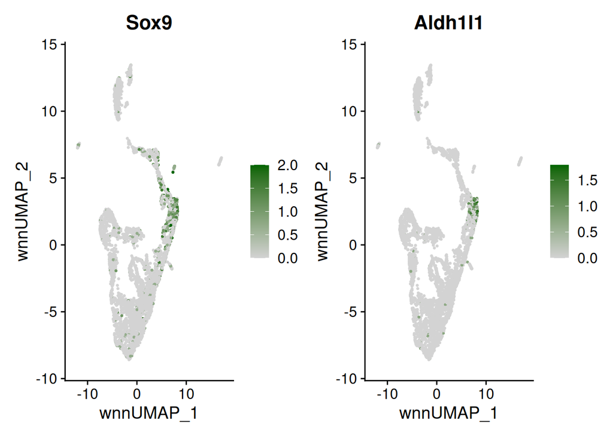

```r
# plot together with some common Astrocyte marker genes
FeaturePlot(mbrain, features = c("Sox9", "Aldh1l1"),
                  reduction = 'wnn.umap', max.cutoff = 2,
                  cols = c("lightgrey","darkgreen"), ncol = 2)
```

c5 seems like a good fit for Astrocytes

### Oligodendrocytes

```r
top.annot %>%
  dplyr::filter(str_detect(celltype, "Oligo"))
```

```
## # A tibble: 6 × 3
##   cluster celltype             n
##   <fct>   <chr>            <int>
## 1 9       Oligodendrocytes     3
## 2 10      Oligodendrocytes     3
## 3 12      Oligodendrocytes    11
## 4 13      Oligodendrocytes     8
## 5 15      Oligodendrocytes     7
## 6 16      Oligodendrocytes     7
```

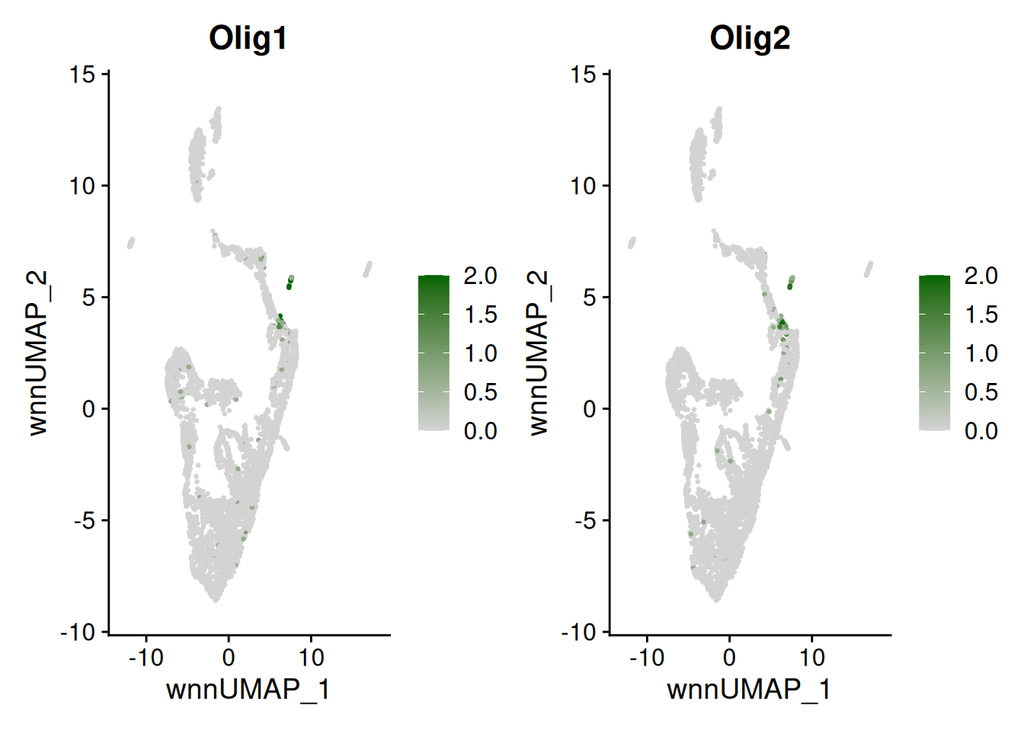

```r
# plot together with some common Oligodendrocyte marker genes
FeaturePlot(mbrain, features = c("Olig1", "Olig2"),
                  reduction = 'wnn.umap', max.cutoff = 2,
                  cols = c("lightgrey","darkgreen"), ncol = 2)
```

c12 seems to be Oligdendrocytes. It may be that a portion of this cluster is misclassified. c12 contains a long ‘neck’, but only a small part of this structure expresses Olig1 and Olig2.

## Progenitor cells

### Immature dentate granule cells

```r
top.annot %>%
  dplyr::filter(str_detect(celltype, "ranule"))
```

```
## # A tibble: 7 × 3
##   cluster celltype                        n
##   <fct>   <chr>                       <int>
## 1 1       Immature Granule Cells (DG)     6
## 2 8       Mature Granule Cells (DG)       4
## 3 10      Mature Granule Cells (DG)       3
## 4 11      Immature Granule Cells (DG)    10
## 5 11      Mature Granule Cells (DG)       8
## 6 13      Immature Granule Cells (DG)     5
## 7 15      Mature Granule Cells (DG)       5
```

c11 are most likely immature granule cells

### Radial glial cells

```r
top.annot %>%
  dplyr::filter(str_detect(celltype, "Radial"))
```

```
## # A tibble: 2 × 3
##   cluster celltype               n
##   <fct>   <chr>              <int>
## 1 5       Radial glial cells    10
## 2 12      Radial glial cells     9
```

c5 and c12 are probably astrocytes and oligodendrocytes, see above.

### Neural progenitors

```r
top.annot %>%
  dplyr::filter(str_detect(celltype, "Progen"))
```

```
## # A tibble: 7 × 3
##   cluster celltype                    n
##   <fct>   <chr>                   <int>
## 1 1       Neural Progenitor cells     3
## 2 2       Neural Progenitor cells     3
## 3 5       Neural Progenitor cells     8
## 4 6       Neural Progenitor cells     3
## 5 7       Neural Progenitor cells     3
## 6 12      Neural Progenitor cells     8
## 7 14      Neural Progenitor cells     4
```

This sample being embryonic mouse brain, many clusters express genes associated with developing neurons. c1 and c2 are likely quite basal neuronal progenitor cells, as they fittingly represent large pools that other cell types may develop from.

## other cells

### Microglia

```r
top.annot %>%
  dplyr::filter(str_detect(celltype, "[Mm]icro"))
```

```
## # A tibble: 9 × 3
##   cluster celltype                n
##   <fct>   <chr>               <int>
## 1 2       Microglial cells        5
## 2 3       Microglial cells        3
## 3 6       Activated Microglia     4
## 4 9       Microglial cells        3
## 5 10      Microglial cells        3
## 6 15      Microglial cells        4
## 7 16      Activated Microglia    32
## 8 16      Resident Microglia     22
## 9 16      Microglial cells       19
```

c16 are microglial cells

### left clusters

```r
top.annot %>%
  dplyr::filter(cluster == 15)
```

```
## # A tibble: 10 × 3
##    cluster celltype                      n
##    <fct>   <chr>                     <int>
##  1 15      Cajal-Retzius                 7
##  2 15      Oligodendrocytes              7
##  3 15      Pericytes                     7
##  4 15      CA1-dorsal Principal          5
##  5 15      Dentate Hilum (CA4)           5
##  6 15      Mature Granule Cells (DG)     5
##  7 15      Fibroblast-like               4
##  8 15      Mature neurons                4
##  9 15      Microglial cells              4
## 10 15      Polydendrocytes               4
```

c15 are most likely embryonic cajal cells

# Cluster identification

1 -> Neural Progenitor 2 -> Neural Progenitor 3 -> Glutamatergic Neuron 4 -> Neural Progenitor 5 -> Astrocytes 6 -> GABAergic Precursor 7 -> GABAergic Neuron 8 -> Neural Progenitor 9 -> Glutamatergic Precursor 10 -> Neural Progenitor 11 -> Immature Granule Cell 12 -> Oligodendrocytes 13 -> Glutamatergic Neuron 14 -> GABAergic Neuron 15 -> Cajal cells 16 -> Microglial cells

```r
mbrain <- mbrain %>%
  RenameIdents(
    '1' = 'Neural Progenitor','2' = 'Neural Progenitor', '4' = 'Neural Progenitor', '8' = 'Neural Progenitor', '10' = 'Neural Progenitor',
    '3' = 'Glutamatergic Neuron', '13' ='Glutamatergic Neuron',
    '9' = 'Glutamatergic Precursor',
    '7' = 'GABAergic Neuron', '14' ='GABAergic Neuron',
    '6' = 'GABAergic Precursor',
    '5' = 'Astrocytes',
    '12' = 'Oligodendrocytes',
    '15' = 'Cajal cells',
    '16' = 'Microglial cells',
    '11' = 'Immature dentate Granule Cells')

mbrain$celltype <- Idents(mbrain)
```

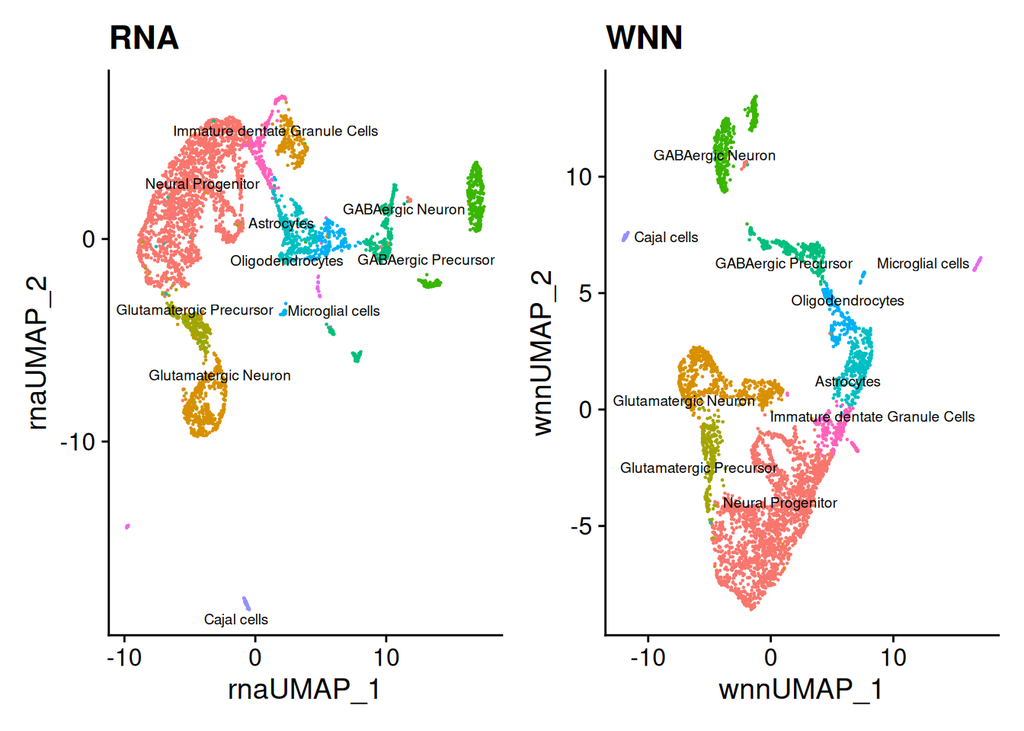

```r
p1 <- DimPlot(mbrain, reduction = "umap.rna", label = TRUE, label.size = 2.5, repel = TRUE, pt.size = 1e-2) + ggtitle("RNA")
p2 <- DimPlot(mbrain, reduction = "wnn.umap", label = TRUE, label.size = 2.5, repel = TRUE, pt.size = 1e-2) + ggtitle("WNN")
p1 + p2 & NoLegend()
```

```r
ggsave("../figures/umap.RNA.WNN.celltypes.png", dpi=300, width = 8, height = 4)
```

```r
saveRDS(mbrain, file = "../data/mbrain_seurat_celltypes.rds")
```